# Group project for R Programming

Analysis of the YouTube dataset

Group 6

30 October 2025

**Load packages**

```r
rm(list = ls()) #clean current workspace
library(tidyverse)
library(dplyr)
library(ggplot2)
library(janitor) # for consistent column naming
library(skimr) # skim/summarize datasets
library(gmodels) # statistical functions, like CrossTable()
library(scales) # format numbers, axes, and labels in ggplot2
library(forcats) # work with categorical variables (factors)
library(reshape2) #heatmap
library(ggcorrplot) # heatmap
library(RColorBrewer) # color palettes for plots
library(readr) # read and write data
library(e1071) # skewness
library(psych) # correlation table
library(patchwork) # combine multiple ggplot2 plots into one layout
library(tidytext) # tokenize texts
library(Hmisc) # correlation matrix
library(countrycode)# for adding the continents
library(stopwords)   # multilingual stop-word lists
library(MASS) # for the rlm regression
library(GGally)      # ggpairs()
library(stringr) #working with texts
library(modelsummary) # summary regression models
library(broom)  # statistical model outputs, functions tidy(), glance()
```

**Load dataset**

```r
#options(scipen = 9999) #show real numbers,nice for a first look at the data, more intuitive to interpret
youtube <- read.csv("youtube_data.csv") #youtube dataset should be in the same folder with this code file
```

# 1 DATA PREPROCESSING

## 1.1 Basic exploration

```r
head(youtube) # Check the first few rows
```

```
##   rank                   Youtuber subscribers  video.views         category
## 1    1                   T-Series   245000000 228000000000            Music
## 2    2             YouTube Movies   170000000            0 Film & Animation
## 3    3                    MrBeast   166000000  28368841870    Entertainment
## 4    4 Cocomelon - Nursery Rhymes   162000000 164000000000        Education
## 5    5                  SET India   159000000 148000000000            Shows
## 6    6                      Music   119000000            0
##                        Title uploads       Country Abbreviation  channel_type
## 1                   T-Series   20082         India           IN         Music
## 2              youtubemovies       1 United States           US         Games
## 3                    MrBeast     741 United States           US Entertainment
## 4 Cocomelon - Nursery Rhymes     966 United States           US     Education
## 5                  SET India  116536         India           IN Entertainment
## 6                      Music       0                                    Music
##   video_views_rank country_rank channel_type_rank
```

[output cut: 62 more lines]

```r
View(youtube) # View all dataset in tabular form in another window

youtube <- youtube %>% clean_names() # standardize column names, all starting with small cases
# Transform blank value into NA, reflecting real missing values, necessary for the next functions to recognize blank spaces as missing values
for (col in names(youtube)) {
  if (is.factor(youtube[[col]]) || is.character(youtube[[col]]))
  {
    youtube[[col]][youtube[[col]] == ""]  <- NA
  }
}

glimpse(youtube) # structure of the dataset
```

```
## Rows: 995
## Columns: 38
## $ rank                                <int> 1, 2, 3, 4, 5, 6, 7, 8, 9, 10, 11,…
## $ youtuber                            <chr> "T-Series", "YouTube Movies", "MrB…
## $ subscribers                         <int> 245000000, 170000000, 166000000, 1…
## $ video_views                         <dbl> 228000000000, 0, 28368841870, 1640…
## $ category                            <chr> "Music", "Film & Animation", "Ente…
## $ title                               <chr> "T-Series", "youtubemovies", "MrBe…
## $ uploads                             <int> 20082, 1, 741, 966, 116536, 0, 111…
## $ country                             <chr> "India", "United States", "United …
## $ abbreviation                        <chr> "IN", "US", "US", "US", "IN", NA, …
## $ channel_type                        <chr> "Music", "Games", "Entertainment",…
## $ video_views_rank                    <dbl> 1, 4055159, 48, 2, 3, 4057944, 5, …
## $ country_rank                        <dbl> 1, 7670, 1, 2, 2, NA, 3, 1, 5, 5, …
## $ channel_type_rank                   <dbl> 1, 7423, 1, 1, 2, NA, 3, 4, 25, 6,…
```

[output cut: 25 more lines]

```r
summary(youtube) # summarize statistical features
```

```
##       rank         youtuber          subscribers         video_views
##  Min.   :  1.0   Length:995         Min.   : 12300000   Min.   :0.000e+00
##  1st Qu.:249.5   Class :character   1st Qu.: 14500000   1st Qu.:4.288e+09
##  Median :498.0   Mode  :character   Median : 17700000   Median :7.761e+09
##  Mean   :498.0                      Mean   : 22982412   Mean   :1.104e+10
##  3rd Qu.:746.5                      3rd Qu.: 24600000   3rd Qu.:1.355e+10
##  Max.   :995.0                      Max.   :245000000   Max.   :2.280e+11
##
##    category            title              uploads           country
##  Length:995         Length:995         Min.   :     0.0   Length:995
##  Class :character   Class :character   1st Qu.:   194.5   Class :character
##  Mode  :character   Mode  :character   Median :   729.0   Mode  :character
##                                        Mean   :  9187.1
##                                        3rd Qu.:  2667.5
##                                        Max.   :301308.0
##
##  abbreviation       channel_type       video_views_rank     country_rank
##  Length:995         Length:995         Min.   :      1.0   Min.   :   1.0
##  Class :character   Class :character   1st Qu.:    323.0   1st Qu.:  11.0
##  Mode  :character   Mode  :character   Median :    915.5   Median :  51.0
##                                        Mean   : 554248.9   Mean   : 386.1
##                                        3rd Qu.:   3584.5   3rd Qu.: 123.0
##                                        Max.   :4057944.0   Max.   :7741.0
##                                        NA's   :1           NA's   :116
##  channel_type_rank video_views_for_the_last_30_days lowest_monthly_earnings
##  Min.   :   1.0    Min.   :1.000e+00                Min.   :     0
##  1st Qu.:  27.0    1st Qu.:2.014e+07                1st Qu.:  2700
##  Median :  65.5    Median :6.408e+07                Median : 13300
##  Mean   : 745.7    Mean   :1.756e+08                Mean   : 36886
##  3rd Qu.: 139.8    3rd Qu.:1.688e+08                3rd Qu.: 37900
##  Max.   :7741.0    Max.   :6.589e+09                Max.   :850900
##  NA's   :33        NA's   :56
##  highest_monthly_earnings lowest_yearly_earnings highest_yearly_earnings
##  Min.   :       0         Min.   :       0       Min.   :        0
##  1st Qu.:   43500         1st Qu.:   32650       1st Qu.:   521750
##  Median :  212700         Median :  159500       Median :  2600000
##  Mean   :  589808         Mean   :  442257       Mean   :  7081814
##  3rd Qu.:  606800         3rd Qu.:  455100       3rd Qu.:  7300000
##  Max.   :13600000         Max.   :10200000       Max.   :163400000
##
```

[output cut: 33 more lines]

```
##  Min.   : 0.0000     Min.   :0.0000       Min.   :      0
##  1st Qu.: 0.5281     1st Qu.:0.3960       1st Qu.:  23100
##  Median : 0.7663     Median :0.8644       Median : 113000
##  Mean   : 1.5773     Mean   :   Inf       Mean   : 313347
##  3rd Qu.: 1.5748     3rd Qu.:1.7302       3rd Qu.: 322350
##  Max.   :34.1837     Max.   :   Inf       Max.   :7225450
##  NA's   :337         NA's   :56
##  country_gdp_per_capita_est  continent         channel_age_category
##  Min.   : 9940              Length:995         Length:995
##  1st Qu.:28595              Class :character   Class :character
##  Median :49200              Mode  :character   Mode  :character
##  Mean   :46358
##  3rd Qu.:62330
##  Max.   :78515
##  NA's   :123
```

```r
skim(youtube) # skim data
```

Data summary

| Name | youtube |
| --- | --- |
| Number of rows | 995 |
| Number of columns | 38 |
| _______________________ |  |
| Column type frequency: |  |
| character | 9 |
| numeric | 29 |
| ________________________ |  |
| Group variables | None |

**Variable type: character**

| skim_variable | n_missing | complete_rate | min | max | empty | n_unique | whitespace |
| --- | --- | --- | --- | --- | --- | --- | --- |
| youtuber | 0 | 1.00 | 2 | 51 | 0 | 995 | 0 |
| category | 46 | 0.95 | 5 | 21 | 0 | 18 | 0 |
| title | 0 | 1.00 | 2 | 49 | 0 | 992 | 0 |
| country | 122 | 0.88 | 4 | 20 | 0 | 49 | 0 |
| abbreviation | 122 | 0.88 | 2 | 2 | 0 | 49 | 0 |
| channel_type | 30 | 0.97 | 4 | 13 | 0 | 14 | 0 |
| created_month | 5 | 0.99 | 3 | 3 | 0 | 12 | 0 |
| continent | 0 | 1.00 | 4 | 13 | 0 | 6 | 0 |
| channel_age_category | 5 | 0.99 | 3 | 11 | 0 | 3 | 0 |

**Variable type: numeric**

| skim_variable | n_missing | complete_rate | mean | sd | p0 | p25 | p50 | p75 | p100 | hist |
| --- | --- | --- | --- | --- | --- | --- | --- | --- | --- | --- |
| rank | 0 | 1.00 | 4.980000e+02 | 2.873800e+02 | 1.00 | 249.50 | 498.00 | 7.465000e+02 | 9.950000e+02 | ▇▇▇▇▇ |
| subscribers | 0 | 1.00 | 2.298241e+07 | 1.752611e+07 | 12300000.00 | 14500000.00 | 17700000.00 | 2.460000e+07 | 2.450000e+08 | ▇▁▁▁▁ |
| video_views | 0 | 1.00 | 1.103954e+10 | 1.411084e+10 | 0.00 | 4288145410.00 | 7760819588.00 | 1.355470e+10 | 2.280000e+11 | ▇▁▁▁▁ |
| uploads | 0 | 1.00 | 9.187130e+03 | 3.415135e+04 | 0.00 | 194.50 | 729.00 | 2.667500e+03 | 3.013080e+05 | ▇▁▁▁▁ |
| video_views_rank | 1 | 1.00 | 5.542489e+05 | 1.362782e+06 | 1.00 | 323.00 | 915.50 | 3.584500e+03 | 4.057944e+06 | ▇▁▁▁▁ |
| country_rank | 116 | 0.88 | 3.860500e+02 | 1.232240e+03 | 1.00 | 11.00 | 51.00 | 1.230000e+02 | 7.741000e+03 | ▇▁▁▁▁ |
| channel_type_rank | 33 | 0.97 | 7.457200e+02 | 1.944390e+03 | 1.00 | 27.00 | 65.50 | 1.397500e+02 | 7.741000e+03 | ▇▁▁▁▁ |
| video_views_for_the_last_30_days | 56 | 0.94 | 1.756103e+08 | 4.163782e+08 | 1.00 | 20137500.00 | 64085000.00 | 1.688265e+08 | 6.589000e+09 | ▇▁▁▁▁ |
| lowest_monthly_earnings | 0 | 1.00 | 3.688615e+04 | 7.185872e+04 | 0.00 | 2700.00 | 13300.00 | 3.790000e+04 | 8.509000e+05 | ▇▁▁▁▁ |
| highest_monthly_earnings | 0 | 1.00 | 5.898078e+05 | 1.148622e+06 | 0.00 | 43500.00 | 212700.00 | 6.068000e+05 | 1.360000e+07 | ▇▁▁▁▁ |
| lowest_yearly_earnings | 0 | 1.00 | 4.422574e+05 | 8.612161e+05 | 0.00 | 32650.00 | 159500.00 | 4.551000e+05 | 1.020000e+07 | ▇▁▁▁▁ |
| highest_yearly_earnings | 0 | 1.00 | 7.081814e+06 | 1.379704e+07 | 0.00 | 521750.00 | 2600000.00 | 7.300000e+06 | 1.634000e+08 | ▇▁▁▁▁ |
| subscribers_for_last_30_days | 337 | 0.66 | 3.490791e+05 | 6.143554e+05 | 1.00 | 100000.00 | 200000.00 | 4.000000e+05 | 8.000000e+06 | ▇▁▁▁▁ |
| created_year | 5 | 0.99 | 2.012630e+03 | 4.510000e+00 | 1970.00 | 2009.00 | 2013.00 | 2.016000e+03 | 2.022000e+03 | ▁▁▁▅▇ |
| created_date | 5 | 0.99 | 1.575000e+01 | 8.780000e+00 | 1.00 | 8.00 | 16.00 | 2.300000e+01 | 3.100000e+01 | ▇▇▇▇▆ |
| gross_tertiary_education_enrollment | 123 | 0.88 | 6.363000e+01 | 2.611000e+01 | 7.60 | 36.30 | 68.00 | 8.820000e+01 | 1.131000e+02 | ▃▂▃▇▁ |
| population | 123 | 0.88 | 4.303873e+08 | 4.727947e+08 | 202506.00 | 83355411.00 | 328239523.00 | 3.282395e+08 | 1.397715e+09 | ▇▆▁▁▃ |
| unemployment_rate | 123 | 0.88 | 9.280000e+00 | 4.890000e+00 | 0.75 | 5.27 | 9.37 | 1.470000e+01 | 1.472000e+01 | ▂▆▁▁▇ |
| urban_population | 123 | 0.88 | 2.242150e+08 | 1.546874e+08 | 35588.00 | 55908316.00 | 270663028.00 | 2.706630e+08 | 8.429340e+08 | ▇▇▃▁▁ |
| latitude | 123 | 0.88 | 2.663000e+01 | 2.056000e+01 | -38.42 | 20.59 | 37.09 | 3.709000e+01 | 6.192000e+01 | ▁▂▅▇▂ |
| longitude | 123 | 0.88 | -1.413000e+01 | 8.476000e+01 | -172.10 | -95.71 | -51.93 | 7.896000e+01 | 1.382500e+02 | ▁▇▂▁▅ |
| avg_views_per_video | 43 | 0.96 | 4.334350e+08 | 2.393801e+09 | 0.00 | 2190180.18 | 7651218.47 | 2.933301e+07 | 3.068634e+10 | ▇▁▁▁▁ |
| subscribers_per_video | 43 | 0.96 | 1.277935e+06 | 7.952307e+06 | 45.23 | 7328.66 | 23307.78 | 7.935080e+04 | 1.700000e+08 | ▇▁▁▁▁ |
| earnings_per_view | 8 | 0.99 | 0.000000e+00 | 0.000000e+00 | 0.00 | 0.00 | 0.00 | 0.000000e+00 | 3.000000e-02 | ▇▁▁▁▁ |
| channel_age_years | 5 | 0.99 | 1.237000e+01 | 4.510000e+00 | 3.00 | 9.00 | 12.00 | 1.600000e+01 | 5.500000e+01 | ▇▅▁▁▁ |
| sub_growth_rate_30d | 337 | 0.66 | 1.580000e+00 | 2.540000e+00 | 0.00 | 0.53 | 0.77 | 1.570000e+00 | 3.418000e+01 | ▇▁▁▁▁ |
| view_growth_rate_30d | 56 | 0.94 | Inf | NaN | 0.00 | 0.40 | 0.86 | 1.730000e+00 | Inf | ▇▁▁▁▁ |
| avg_monthly_earnings | 0 | 1.00 | 3.133470e+05 | 6.102391e+05 | 0.00 | 23100.00 | 113000.00 | 3.223500e+05 | 7.225450e+06 | ▇▁▁▁▁ |
| country_gdp_per_capita_est | 123 | 0.88 | 4.635804e+04 | 1.696948e+04 | 9940.00 | 28595.00 | 49200.00 | 6.233000e+04 | 7.851500e+04 | ▃▂▃▇▁ |

```r
str(youtube)
```

```
## 'data.frame':    995 obs. of  38 variables:
##  $ rank                               : int  1 2 3 4 5 6 7 8 9 10 ...
##  $ youtuber                           : chr  "T-Series" "YouTube Movies" "MrBeast" "Cocomelon - Nursery Rhymes" ...
##  $ subscribers                        : int  245000000 170000000 166000000 162000000 159000000 119000000 112000000 111000000 106000000 98900000 ...
##  $ video_views                        : num  2.28e+11 0.00 2.84e+10 1.64e+11 1.48e+11 ...
##  $ category                           : chr  "Music" "Film & Animation" "Entertainment" "Education" ...
##  $ title                              : chr  "T-Series" "youtubemovies" "MrBeast" "Cocomelon - Nursery Rhymes" ...
##  $ uploads                            : int  20082 1 741 966 116536 0 1111 4716 493 574 ...
##  $ country                            : chr  "India" "United States" "United States" "United States" ...
##  $ abbreviation                       : chr  "IN" "US" "US" "US" ...
##  $ channel_type                       : chr  "Music" "Games" "Entertainment" "Education" ...
##  $ video_views_rank                   : num  1 4055159 48 2 3 ...
##  $ country_rank                       : num  1 7670 1 2 2 NA 3 1 5 5 ...
##  $ channel_type_rank                  : num  1 7423 1 1 2 ...
##  $ video_views_for_the_last_30_days   : num  2.26e+09 1.20e+01 1.35e+09 1.97e+09 1.82e+09 ...
```

[output cut: 24 more lines]

## 1.2 Data cleaning

```r
# Standardize data types, transforming some categorical variables into factor
youtube <- youtube %>%
  mutate(
    created_month = factor(created_month, levels = c("Jan", "Feb", "Mar", "Apr", "May", "Jun", "Jul", "Aug", "Sep", "Oct", "Nov", "Dec")),
    channel_age_category = factor(channel_age_category, levels = c("New", "Established","Veteran")),
    continent = as.factor(continent),
    channel_type = as.factor(channel_type),
    category = as.factor(category)
  )

# Filter out unvalid data
youtube_clean <- youtube %>%
  filter(video_views > 0) %>% #video views as performance measure, only interested in channels with more than 0 video views
  filter(is.na(video_views_for_the_last_30_days) | video_views >= video_views_for_the_last_30_days) %>%#drop observations where the total number of views is smaller than the views in the last 30 days because these observations are contrydictary.
  filter(is.na(channel_age_years) |channel_age_years <= 20) # Youtube was founded in 2005, any channel older than that is dropped

# Transform unit, dividing by million for readability
youtube_clean <- youtube_clean %>%
  mutate(subscribers_mil = subscribers/1e6,
         video_views_mil = video_views/1e6,) %>%
  dplyr::select(-c(subscribers, video_views))
```

**Handle dates**

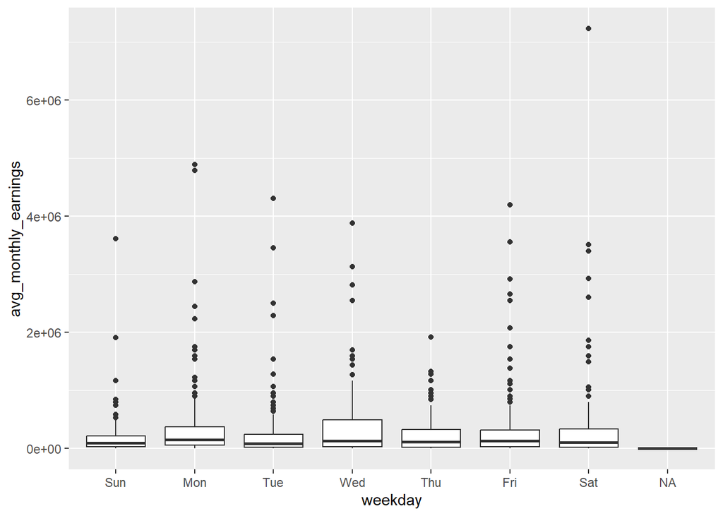

```r
# Convert created_month, created_year, created_day to created_time
 youtube_clean <- youtube_clean %>%
  mutate(created_time = make_date(created_year, created_month, created_date))

# Add weekday
youtube_clean<- youtube_clean%>%
    mutate(weekday = wday(created_time, label = TRUE))

# Factorise weekday and add the order of the weekday
youtube_clean<- youtube_clean%>%
  mutate(weekday= factor(weekday, levels= c("Sun", "Mon", "Tue", "Wed", "Thu", "Fri", "Sat" )))

#Boxplot
ggplot(youtube_clean, aes(weekday, avg_monthly_earnings))+
  geom_boxplot()
```

We leave this out of the report because concluding from the boxplots, the weekday a channel has been created seems to have no influence on how the channel performes (medians are in a similair range).

**Add continents**

```r
#Use the countrycode package to add continents instead of "Other" when info about country is available in the data set.
youtube_clean <- youtube_clean %>%
  mutate(
    continent_1 = if_else(
      continent == "Other",
      countrycode(country, "country.name", "continent"),
      continent
    )
  )

#The package countrycode does not distinguish between South and North America but uses Americas instead. For a consistent coding we first filter the columns which have Americas as entry and change those accordingly.
youtube_clean%>%
  filter(continent_1 == "Americas")%>%
  dplyr::select(country, continent, continent_1)
```

```
##       country continent continent_1
## 1        Cuba     Other    Americas
## 2 El Salvador     Other    Americas
## 3    Barbados     Other    Americas
## 4   Venezuela     Other    Americas
## 5     Ecuador     Other    Americas
## 6        Peru     Other    Americas
## 7     Ecuador     Other    Americas
```

```r
youtube_clean <- youtube_clean %>%
  mutate(
    continent_1 = case_when(
      country %in% c("Cuba", "El Salvador", "Barbados") ~ "North America",
      country %in% c("Venezuela", "Ecuador", "Peru") ~ "South America",
      TRUE ~ continent_1
    )
  )


#Drop the old continent column now and rename continent_1 to continent
youtube_clean<-youtube_clean%>%
  dplyr::select(-c("continent"))%>%
  rename(continent= continent_1)

# Check whether the transformation worked.
youtube_clean%>%
  filter(continent == "Other" | continent== "Americas")%>%
  dplyr::select(country, continent)
```

```
## [1] country   continent
## <0 rows> (or 0-length row.names)
```

```r
# 0 observations with "Other" or "Americas".
```

**Add new variables**

```r
#  Calculate number of youtubers by category and number of youtubers by channel type
youtube_clean <- youtube_clean %>%
  group_by(category) %>%
  mutate(num_category = n()) %>%
  ungroup()

youtube_clean <- youtube_clean %>%
  group_by(channel_type) %>%
  mutate(num_type = n()) %>%
  ungroup()
```

## 1.3 Distribution

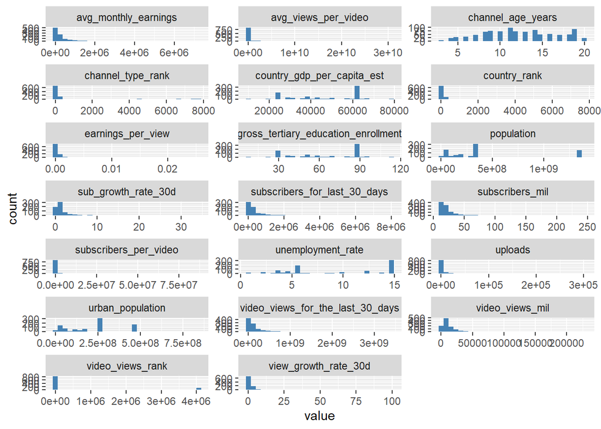

```r
# 1) Histograms to get a general feeling of the skewness of the data/ if there is need to transform data

histogram<-youtube_clean %>%
  dplyr::select(-c(highest_monthly_earnings, highest_yearly_earnings, lowest_monthly_earnings, lowest_yearly_earnings, rank, longitude, latitude, created_date, created_year, num_category, num_type))%>%# deselect variables we don't work with
  keep(is.numeric) %>% #Keep only numeric columns
  gather() %>%                             # Convert to key-value pairs
  ggplot(aes(value)) +                     # Plot the values
  facet_wrap(~ key, scales = "free", , ncol=3, nrow=7) + # In separate panels
  geom_histogram(fill = "steelblue")

ggsave("histogram.pdf", histogram, width = 10, height = 8) #example for how to save a graphic for the report
histogram
```

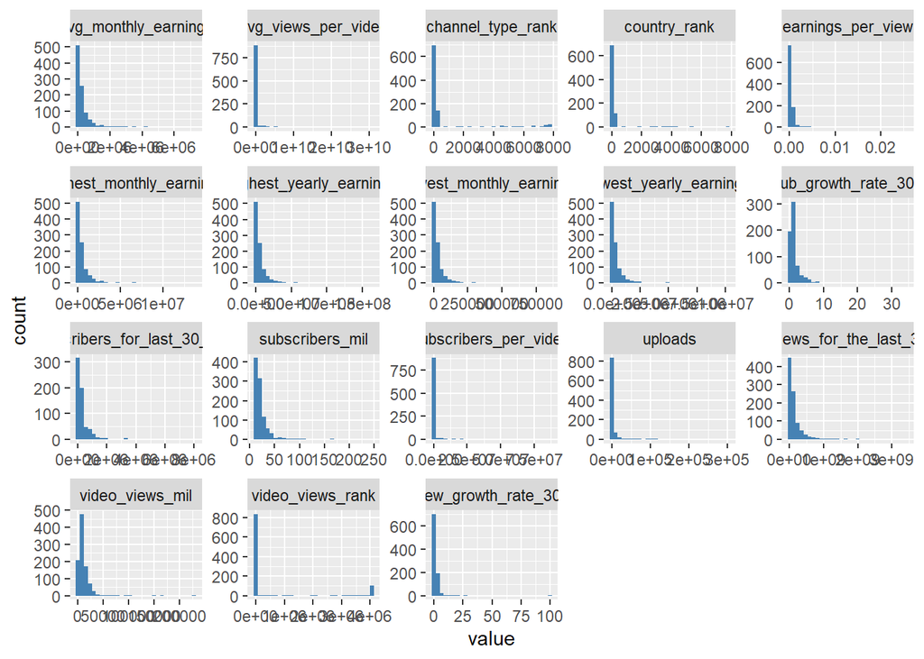

```r
#For the skewness, only keep the right skewed data in the graph
youtube_clean %>%
  keep(is.numeric) %>% #Keep only numeric columns
  dplyr::select(-c( longitude, latitude, created_date, channel_age_years, urban_population, country_gdp_per_capita_est, created_year, gross_tertiary_education_enrollment, unemployment_rate, num_category, num_type, population, urban_population, gross_tertiary_education_enrollment, channel_age_years, country_gdp_per_capita_est, rank))%>% # Deselect non right-skewed data
  gather() %>%                             # Convert to key-value pairs
  ggplot(aes(value)) +                     # Plot the values
  facet_wrap(~ key, scales = "free") + # In separate panels
  geom_histogram(fill = "steelblue")
```

## 1.4 Dealing with outliers under IQR Rule

(marking outliers as >= 1.5 IQR away from first / third Quartile)

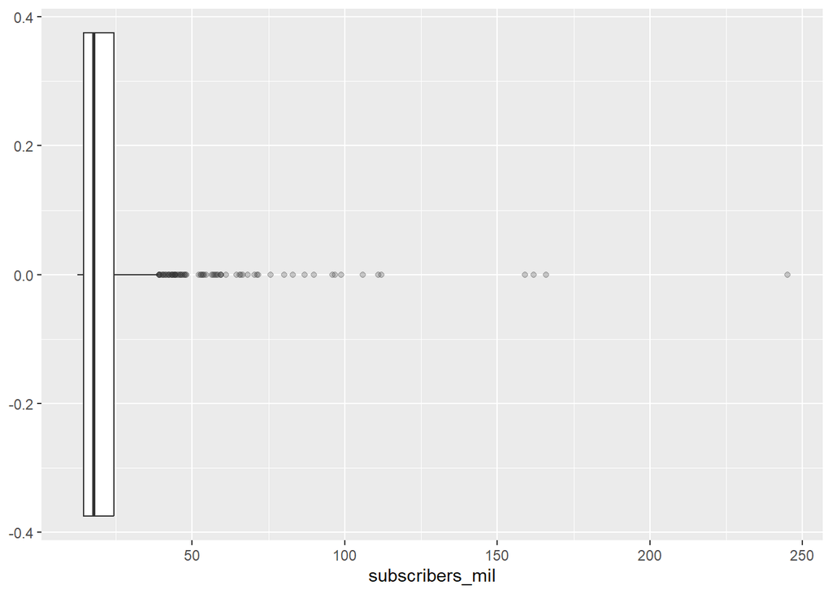

```r
#1) Boxplots to see the distribution of the outliers
ggplot(youtube_clean, aes( subscribers_mil))+
  geom_boxplot(outlier.alpha = 0.25)
```

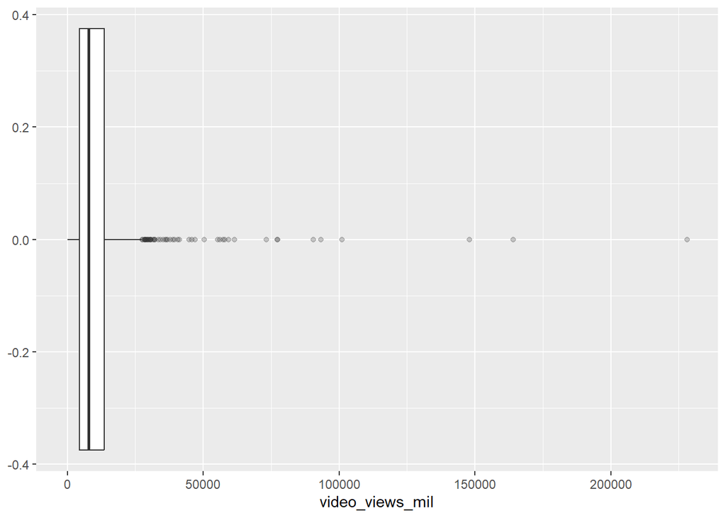

```r
ggplot(youtube_clean, aes( video_views_mil))+
  geom_boxplot(outlier.alpha = 0.25)
```

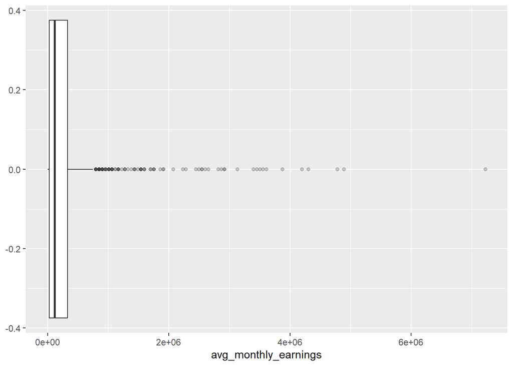

```r
ggplot(youtube_clean, aes(avg_monthly_earnings))+
  geom_boxplot(outlier.alpha = 0.25)
```

```r
# 2) Applying the IQR Rule

iqr_limits <- youtube_clean %>%
  dplyr::select(video_views_mil, subscribers_mil, avg_monthly_earnings) %>%
  pivot_longer(everything(), names_to = "var", values_to = "value") %>%
  group_by(var) %>%
  summarise(
    Q1  = quantile(value, 0.25, na.rm = TRUE),
    Q3  = quantile(value, 0.75, na.rm = TRUE),
    IQR = Q3 - Q1,
    lower = Q1 - 1.5 * IQR,
    upper = Q3 + 1.5 * IQR,
    lower_drops = sum(value < lower, na.rm = TRUE),
    upper_drops = sum(value > upper, na.rm = TRUE),
    total_drops = lower_drops + upper_drops,
    .groups = "drop"
  )

iqr_limits
```

```
## # A tibble: 3 × 9
##   var       Q1     Q3    IQR    lower  upper lower_drops upper_drops total_drops
##   <chr>  <dbl>  <dbl>  <dbl>    <dbl>  <dbl>       <int>       <int>       <int>
## 1 avg_… 2.56e4 3.27e5 3.01e5 -4.27e+5 7.79e5           0          99          99
## 2 subs… 1.45e1 2.43e1 9.8 e0 -2.00e-1 3.9 e1           0          78          78
## 3 vide… 4.38e3 1.36e4 9.24e3 -9.48e+3 2.75e4           0          52          52
```

Applying the IQR would lead to a relatively huge loss of observations. They are not wrong in the sense of measurement errors, so we don’t drop them. But have to be kept in mind when regressing the data. In the next step we log transform some data.

## 1.5 Skewness and Transformation

```r
# 1) Check how skewed the data is
skewness <- youtube_clean %>%
  dplyr::select(where(is.numeric)) %>%
  summarise(across(everything(), ~ skewness(., na.rm = TRUE))) %>%
  pivot_longer(everything(), names_to = "var", values_to = "skewness")

# Filter the right skewed data, for which in theory a log transformation would make sense
skewness %>%
  filter(skewness > 1)
```

```
## # A tibble: 19 × 2
##    var                              skewness
##    <chr>                               <dbl>
##  1 uploads                              5.61
##  2 video_views_rank                     2.20
##  3 country_rank                         4.26
##  4 channel_type_rank                    2.78
##  5 video_views_for_the_last_30_days     4.64
##  6 lowest_monthly_earnings              4.76
##  7 highest_monthly_earnings             4.76
##  8 lowest_yearly_earnings               4.76
##  9 highest_yearly_earnings              4.76
## 10 subscribers_for_last_30_days         6.62
## 11 population                           1.32
## 12 avg_views_per_video                  8.17
## 13 subscribers_per_video                9.43
## 14 earnings_per_view                   16.4
## 15 sub_growth_rate_30d                  5.87
## 16 view_growth_rate_30d                15.9
## 17 avg_monthly_earnings                 4.76
## 18 subscribers_mil                      5.74
## 19 video_views_mil                      7.20
```

```r
# Check if there are zero values before doing log transformation, which leads to infinite results
youtube_clean %>%
  dplyr::select(where(is.numeric)) %>% # only numeric columns
  summarise(across(everything(), ~ sum(. == 0, na.rm = TRUE))) %>%
  pivot_longer(everything(), names_to = "var", values_to = "zeros_count") %>%
  arrange(desc(zeros_count))
```

```
## # A tibble: 31 × 2
##    var                      zeros_count
##    <chr>                          <int>
##  1 lowest_monthly_earnings          106
##  2 highest_monthly_earnings          79
##  3 lowest_yearly_earnings            79
##  4 avg_monthly_earnings              79
##  5 highest_yearly_earnings           70
##  6 earnings_per_view                 70
##  7 uploads                           38
##  8 rank                               0
##  9 video_views_rank                   0
## 10 country_rank                       0
## # ℹ 21 more rows
```

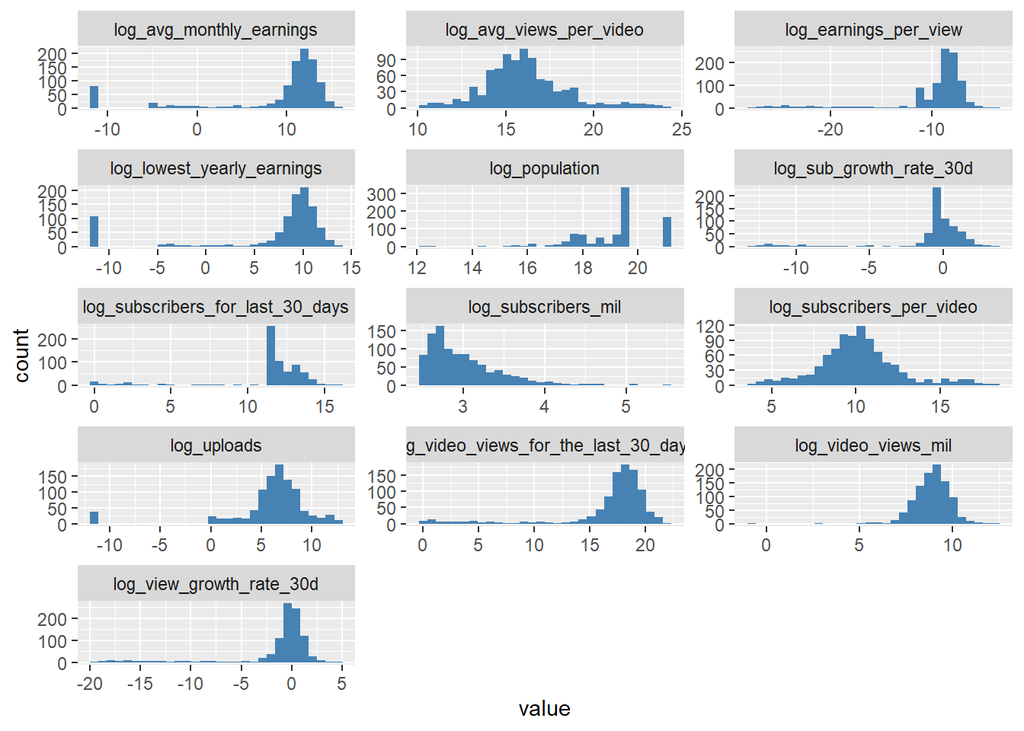

```r
# Transform zeros to very small values close to 0 for log transformation
youtube_clean <- youtube_clean %>%
  mutate(lowest_monthly_earnings = replace(lowest_monthly_earnings, lowest_monthly_earnings == 0, 0.00001),
         highest_monthly_earnings = replace(highest_monthly_earnings, highest_monthly_earnings == 0, 0.00001),
         lowest_yearly_earnings = replace(lowest_monthly_earnings, lowest_monthly_earnings == 0, 0.00001),
         highest_yearly_earnings = replace(highest_monthly_earnings, highest_monthly_earnings == 0, 0.00001),
         avg_monthly_earnings = replace(avg_monthly_earnings, avg_monthly_earnings == 0, 0.00001),
         earnings_per_view = replace(earnings_per_view, earnings_per_view == 0, 0.00001),
         uploads = replace(uploads, uploads == 0, 0.00001)
         )

# Transform right skewed data
youtube_clean<- youtube_clean%>%
  mutate(log_uploads= log(uploads),
         log_video_views_for_the_last_30_days = log(video_views_for_the_last_30_days),
         log_lowest_monthly_earnings= log(lowest_monthly_earnings),
         log_highest_monthly_earnings = log(highest_monthly_earnings),
         log_lowest_yearly_earnings = log( lowest_yearly_earnings),
         log_highest_yearly_earnings = log(highest_yearly_earnings),
         log_subscribers_for_last_30_days = log(subscribers_for_last_30_days),
         log_population= log(population),
         log_avg_views_per_video = log(avg_views_per_video),
         log_subscribers_per_video = log(subscribers_per_video),
         log_earnings_per_view = log(earnings_per_view),
         log_sub_growth_rate_30d = log(sub_growth_rate_30d),
         log_view_growth_rate_30d = log(view_growth_rate_30d),
         log_avg_monthly_earnings = log(avg_monthly_earnings),
         log_subscribers_mil = log(subscribers_mil),
         log_video_views_mil = log(video_views_mil))

youtube_clean_log<- youtube_clean%>%
  dplyr::select(-c(uploads, video_views_for_the_last_30_days,lowest_monthly_earnings, highest_monthly_earnings, lowest_yearly_earnings, highest_yearly_earnings, subscribers_for_last_30_days, population, avg_views_per_video, subscribers_per_video, earnings_per_view, sub_growth_rate_30d, view_growth_rate_30d, avg_monthly_earnings, subscribers_mil, video_views_mil ))

#histograms to check whether the log transformation helped with data representation
youtube_clean_log %>%
  keep(is.numeric) %>% # Keep only numeric columns
  dplyr::select(-c( longitude, latitude, created_date, channel_age_years, urban_population, country_gdp_per_capita_est, created_year, gross_tertiary_education_enrollment, unemployment_rate, num_category, num_type, rank, country_rank, video_views_rank, log_highest_monthly_earnings, log_lowest_monthly_earnings, log_highest_yearly_earnings, log_highest_monthly_earnings, channel_type_rank))%>% #Deselect numerical but discrete data and non_log data
  gather() %>%                             # Convert to key-value pairs
  ggplot(aes(value)) +                     # Plot the values
  facet_wrap(~ key, scales = "free", ncol=3, nrow=5) + # In separate panels
  geom_histogram(fill = "steelblue")                       # As histogram
```

```r
# Check skewness after log transformation
youtube_clean_log %>%
  dplyr::select(where(is.numeric)) %>%
  summarise(across(everything(), ~ skewness(., na.rm = TRUE))) %>%
  pivot_longer(everything(), names_to = "var", values_to = "skewness") %>%
  arrange(desc(skewness))
```

```
## # A tibble: 31 × 2
##    var                       skewness
##    <chr>                        <dbl>
##  1 country_rank               4.26
##  2 channel_type_rank          2.78
##  3 video_views_rank           2.20
##  4 log_subscribers_mil        1.59
##  5 log_avg_views_per_video    0.698
##  6 log_subscribers_per_video  0.504
##  7 urban_population           0.336
##  8 longitude                  0.334
##  9 channel_age_years          0.0132
## 10 num_type                   0.00832
## # ℹ 21 more rows
```

Now some variables are left skewed but to a smaller extent than before. Graphs are closer to a normal distribution which is nice for interpreting the t-statistics.

# 2 EXPLORATION DATA ANALYSIS

## 2.1 Correlation between variables

```r
# Correlation table between variables (for internal review only, please refer to the heatmap below for better visualization)
corr_results <- corr.test(
  youtube_clean[, c("avg_monthly_earnings","subscribers_mil", "video_views_mil", "uploads", "earnings_per_view", "sub_growth_rate_30d", "channel_age_years", "country_gdp_per_capita_est", "unemployment_rate",
         "video_views_for_the_last_30_days", "population", "video_views_rank", "rank")],
  use = "pairwise"
)

r <- corr_results$r
p <- corr_results$p

stars <- ifelse(p < 0.001, "***",
         ifelse(p < 0.01, "**",
         ifelse(p < 0.05, "*", "")))

r_with_stars <- matrix(paste0(round(r, 2), stars),
                       nrow = nrow(r),
                       dimnames = dimnames(r))

corr_table <- as.data.frame(r_with_stars)
corr_table
```

```
##                                  avg_monthly_earnings subscribers_mil
## avg_monthly_earnings                             1***         0.43***
## subscribers_mil                               0.43***            1***
## video_views_mil                               0.55***         0.83***
## uploads                                       0.17***          0.09**
## earnings_per_view                             0.29***           -0.02
## sub_growth_rate_30d                           0.61***           -0.06
## channel_age_years                              -0.07*         0.13***
## country_gdp_per_capita_est                      -0.06           -0.02
## unemployment_rate                               -0.04           -0.02
## video_views_for_the_last_30_days                 1***         0.43***
## population                                      0.1**          0.09**
## video_views_rank                              -0.2***               0
## rank                                         -0.26***        -0.65***
##                                  video_views_mil  uploads earnings_per_view
## avg_monthly_earnings                     0.55***  0.17***           0.29***
## subscribers_mil                          0.83***     0.09             -0.02
## video_views_mil                             1***  0.16***             -0.04
## uploads                                  0.16***     1***              0.01
## earnings_per_view                          -0.04     0.01              1***
## sub_growth_rate_30d                        -0.04    -0.02           0.36***
## channel_age_years                        0.14***  0.17***          -0.16***
## country_gdp_per_capita_est                 -0.01 -0.22***             -0.04
## unemployment_rate                              0 -0.19***             -0.02
## video_views_for_the_last_30_days         0.55***  0.16***           0.28***
## population                                 0.08*  0.14***             0.07*
## video_views_rank                           -0.05 -0.11***          -0.12***
## rank                                    -0.47***    -0.05              0.01
##                                  sub_growth_rate_30d channel_age_years
## avg_monthly_earnings                         0.61***             -0.07
## subscribers_mil                                -0.06            0.13**
## video_views_mil                                -0.04           0.14***
## uploads                                        -0.02           0.17***
## earnings_per_view                            0.36***          -0.16***
## sub_growth_rate_30d                             1***          -0.26***
## channel_age_years                           -0.26***              1***
## country_gdp_per_capita_est                     -0.01           0.16***
## unemployment_rate                              -0.04           0.13***
## video_views_for_the_last_30_days             0.61***            -0.07*
## population                                      0.02          -0.12***
```

[output cut: 29 more lines]

```
## rank                                                     -0.26***      -0.03
##                                  video_views_rank     rank
## avg_monthly_earnings                      -0.2*** -0.26***
## subscribers_mil                                 0 -0.65***
## video_views_mil                             -0.05 -0.47***
## uploads                                    -0.11*    -0.05
## earnings_per_view                          -0.12*     0.01
## sub_growth_rate_30d                      -0.18***     0.05
## channel_age_years                               0    -0.09
## country_gdp_per_capita_est                   0.04    -0.03
## unemployment_rate                           -0.04    -0.01
## video_views_for_the_last_30_days         -0.17*** -0.26***
## population                                   -0.1    -0.03
## video_views_rank                             1***    -0.03
## rank                                        -0.03     1***
```

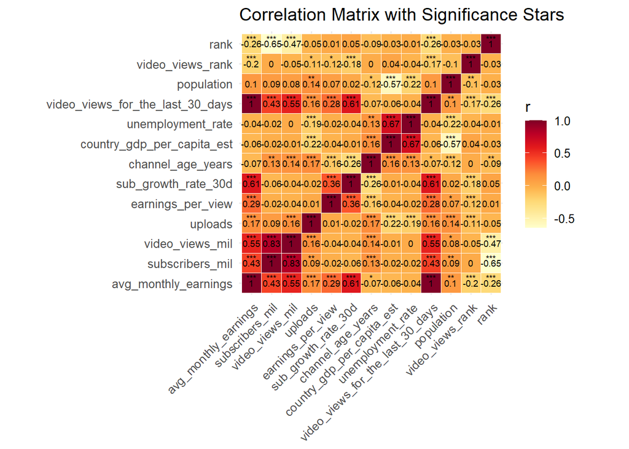

```r
# Heatmap
# Convert matrices to long format
r_long <- melt(r)
p_long <- melt(p)

# Combine correlation and p-value data
heatmap <- left_join(r_long, p_long, by = c("Var1", "Var2"))
colnames(heatmap) <- c("x", "y", "r", "p")

# Create significance stars
heatmap$stars <- ifelse(heatmap$p < 0.001, "***",
             ifelse(heatmap$p < 0.01, "**",
             ifelse(heatmap$p < 0.05, "*", "")))

# Plot using ggplot2
ggplot(heatmap, aes(x, y, fill = r)) +
  geom_tile(color = "white") +
  scale_fill_gradientn(colors = colorRampPalette(brewer.pal(9, "YlOrRd"))(200)) +
  geom_text(aes(label = round(r, 2)), size = 2.5, color = "black") +           # correlation values
  geom_text(aes(label = stars, y = as.numeric(y) + 0.25),                    # stars (offset upward)
            color = "black", size = 2.5) +
  coord_fixed() +
  theme_minimal(base_size = 12) +
  theme(axis.text.x = element_text(angle = 45, vjust = 1, hjust = 1),
        axis.title = element_blank()) +
  labs(title = "Correlation Matrix with Significance Stars",
       fill = "r")
```

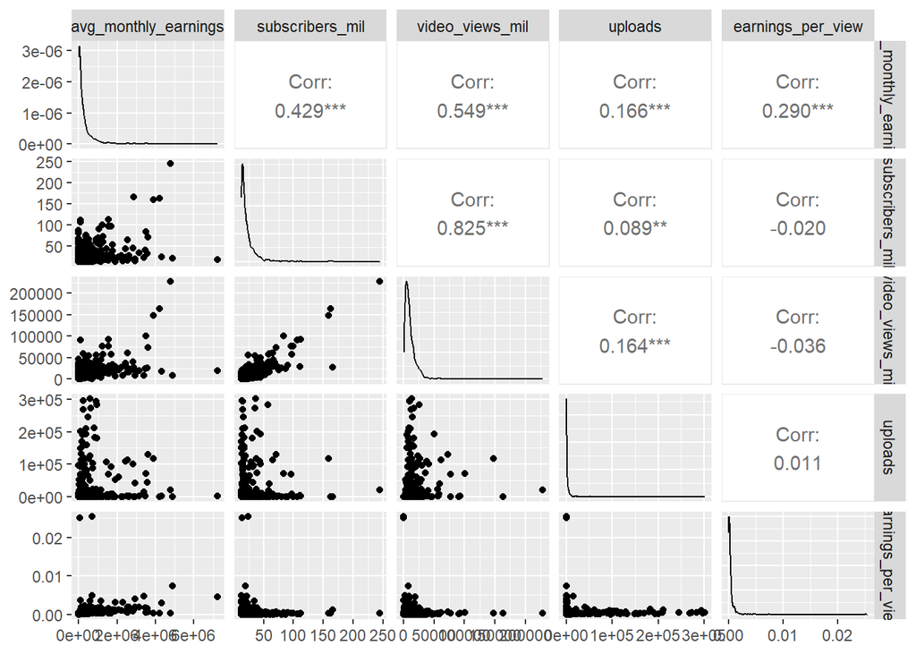

```r
## ggpair plots, not including in the report cause content overlapped with histograms and heatmaps
# Original variables
GGally::ggpairs(youtube_clean[, c("avg_monthly_earnings","subscribers_mil","video_views_mil", "uploads", "earnings_per_view")])
```

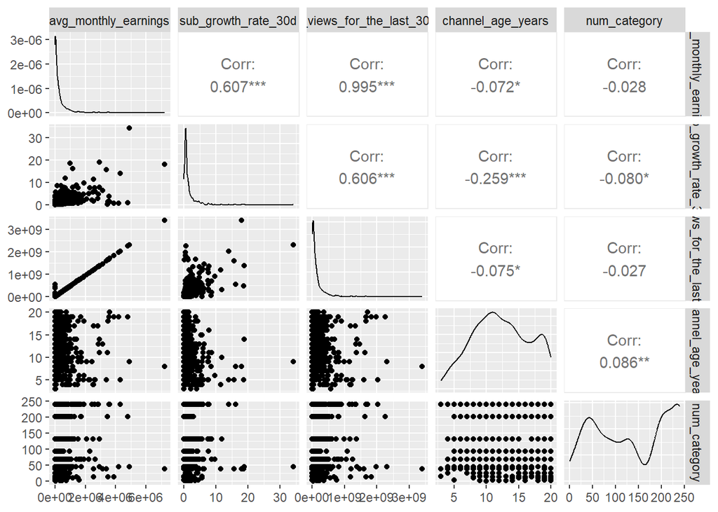

```r
GGally::ggpairs(youtube_clean[, c("avg_monthly_earnings", "sub_growth_rate_30d",
                                  "video_views_for_the_last_30_days","channel_age_years","num_category")])
```

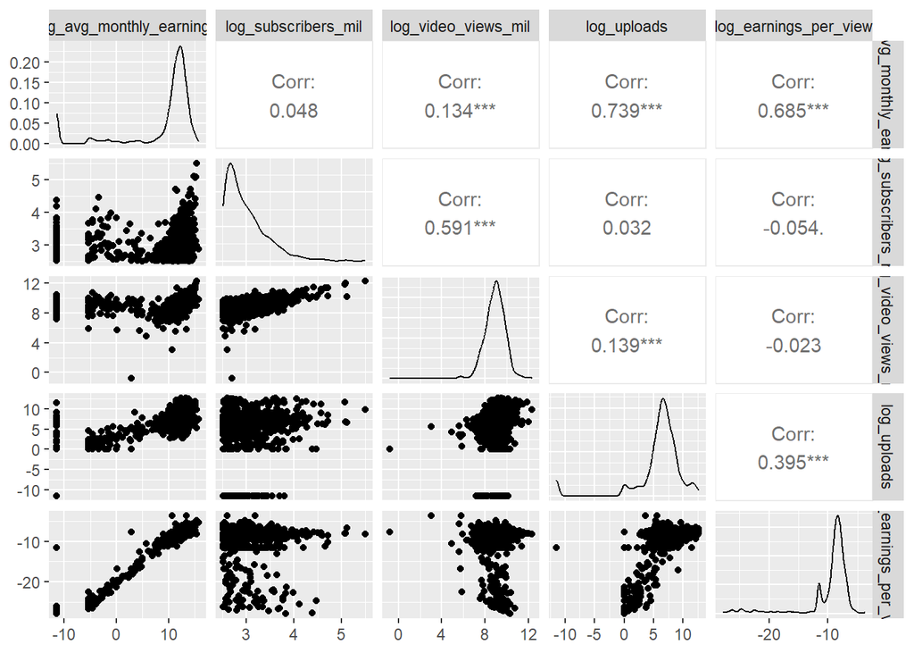

```r
# Log variables
GGally::ggpairs(youtube_clean_log[, c("log_avg_monthly_earnings","log_subscribers_mil","log_video_views_mil", "log_uploads", "log_earnings_per_view")])
```

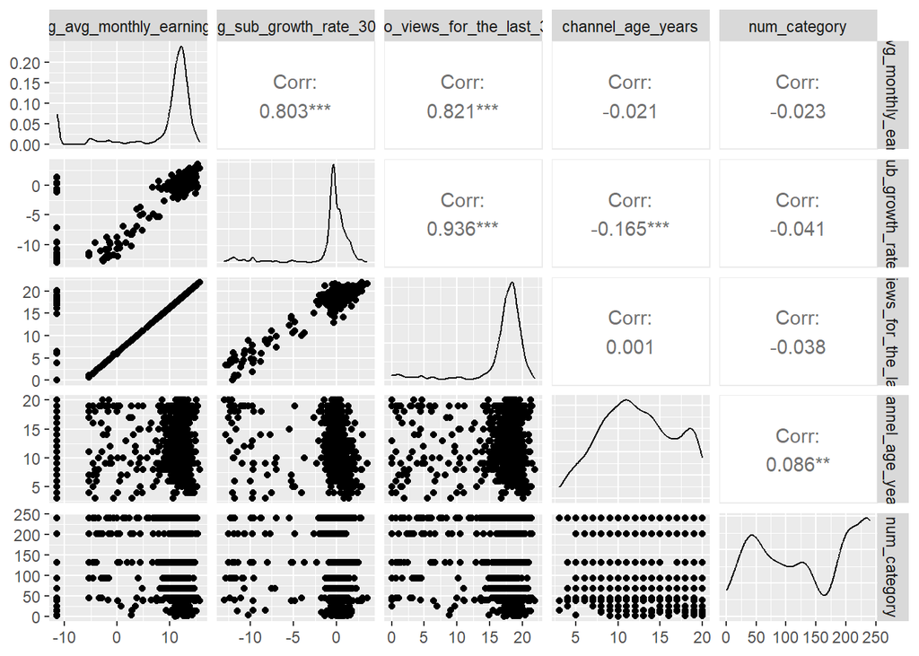

```r
GGally::ggpairs(youtube_clean_log[, c("log_avg_monthly_earnings", "log_sub_growth_rate_30d",
                                  "log_video_views_for_the_last_30_days","channel_age_years", "num_category")])
```

## 2.2 Data visualization

### 2.2.1 Nummerical variables

**Average Monthly Earnings**

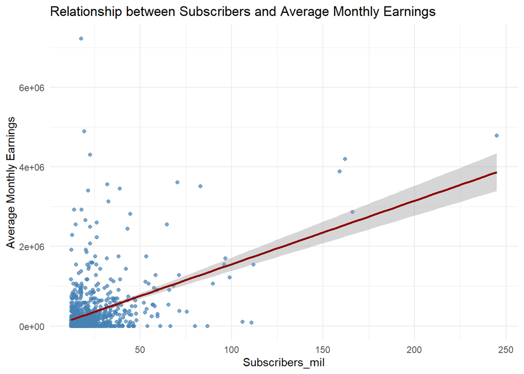

```r
# Average Monthly Earnings by Subscribers
ggplot(youtube_clean, aes(x = subscribers_mil, y = avg_monthly_earnings)) +
  geom_point(color = "steelblue", alpha = 0.7) +
  geom_smooth(method = "lm", se = TRUE, color = "darkred") +
  labs(
    title = "Relationship between Subscribers and Average Monthly Earnings",
    x = "Subscribers_mil",
    y = "Average Monthly Earnings"
  ) +
  theme_minimal()
```

```r
cor(youtube_clean$subscribers_mil, youtube_clean$avg_monthly_earnings, use = "complete.obs")
```

```
## [1] 0.428696
```

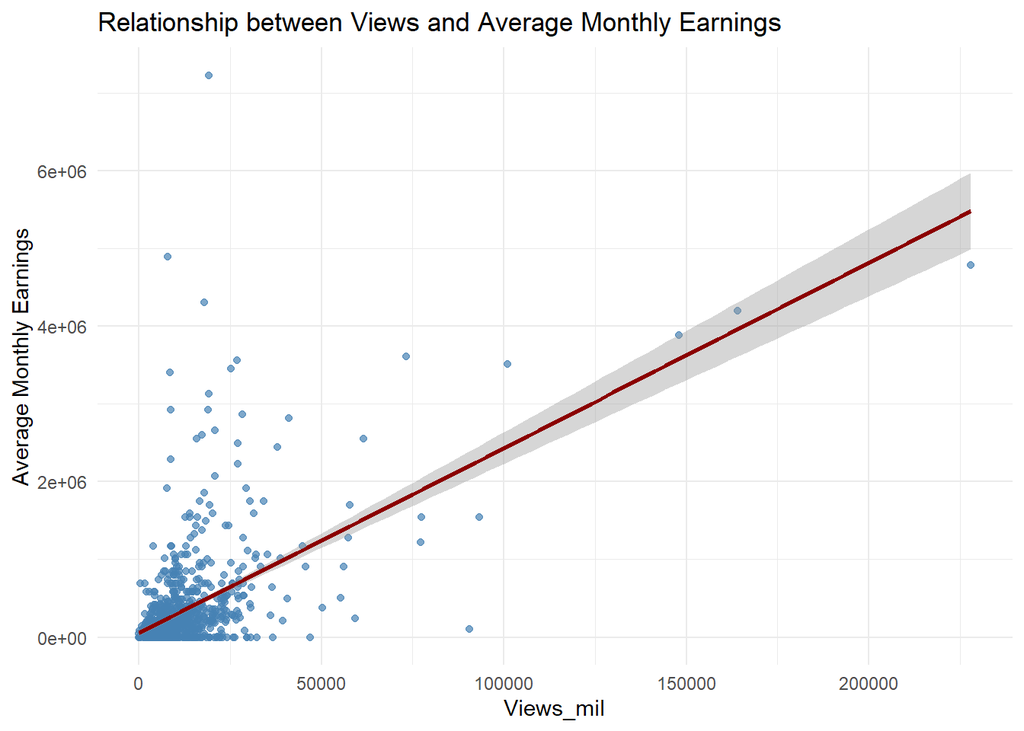

```r
# Average Monthly Earnings by Views
ggplot(youtube_clean, aes(x = video_views_mil, y = avg_monthly_earnings)) +
  geom_point(color = "steelblue", alpha = 0.7) +
  geom_smooth(method = "lm", se = TRUE, color = "darkred") +
  labs(
    title = "Relationship between Views and Average Monthly Earnings",
    x = "Views_mil",
    y = "Average Monthly Earnings"
  ) +
  theme_minimal()
```

```r
cor(youtube_clean$video_views_mil, youtube_clean$avg_monthly_earnings, use = "complete.obs")
```

```
## [1] 0.5494444
```

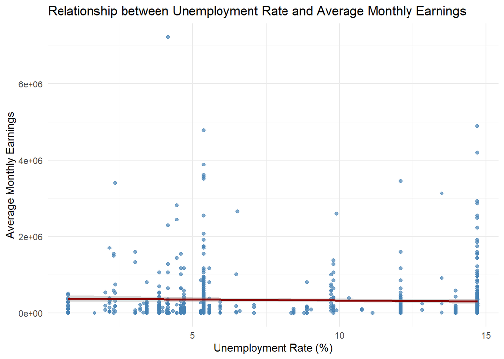

```r
# Average Monthly Earnings by Unemployment Rate
ggplot(youtube_clean, aes(x = unemployment_rate, y = avg_monthly_earnings)) +
  geom_point(color = "steelblue", alpha = 0.7) +
  geom_smooth(method = "lm", se = TRUE, color = "darkred") +
  labs(
    title = "Relationship between Unemployment Rate and Average Monthly Earnings",
    x = "Unemployment Rate (%)",
    y = "Average Monthly Earnings"
  ) +
  theme_minimal()
```

```r
cor(youtube_clean$unemployment_rate, youtube_clean$avg_monthly_earnings, use = "complete.obs")
```

```
## [1] -0.0397229
```

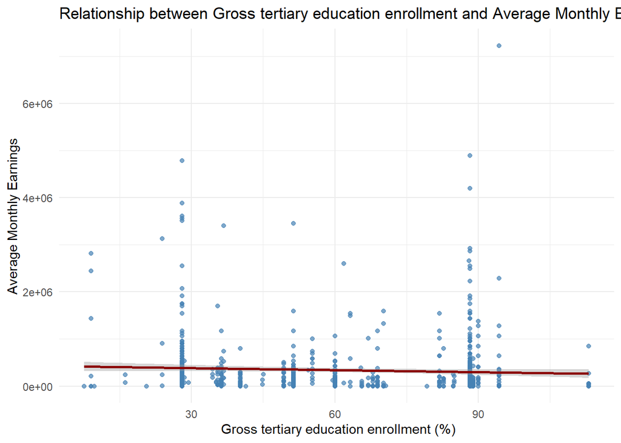

```r
# Average Monthly Earnings by Gross tertiary education enrollment
ggplot(youtube_clean, aes(x = gross_tertiary_education_enrollment, y = avg_monthly_earnings)) +
  geom_point(color = "steelblue", alpha = 0.7) +
  geom_smooth(method = "lm", se = TRUE, color = "darkred") +
  labs(
    title = "Relationship between Gross tertiary education enrollment and Average Monthly Earnings",
    x = " Gross tertiary education enrollment (%)",
    y = "Average Monthly Earnings"
  ) +
  theme_minimal()
```

```r
cor(youtube_clean$gross_tertiary_education_enrollment, youtube_clean$avg_monthly_earnings, use = "complete.obs")
```

```
## [1] -0.06034729
```

**Subscribers Monthly Earnings**

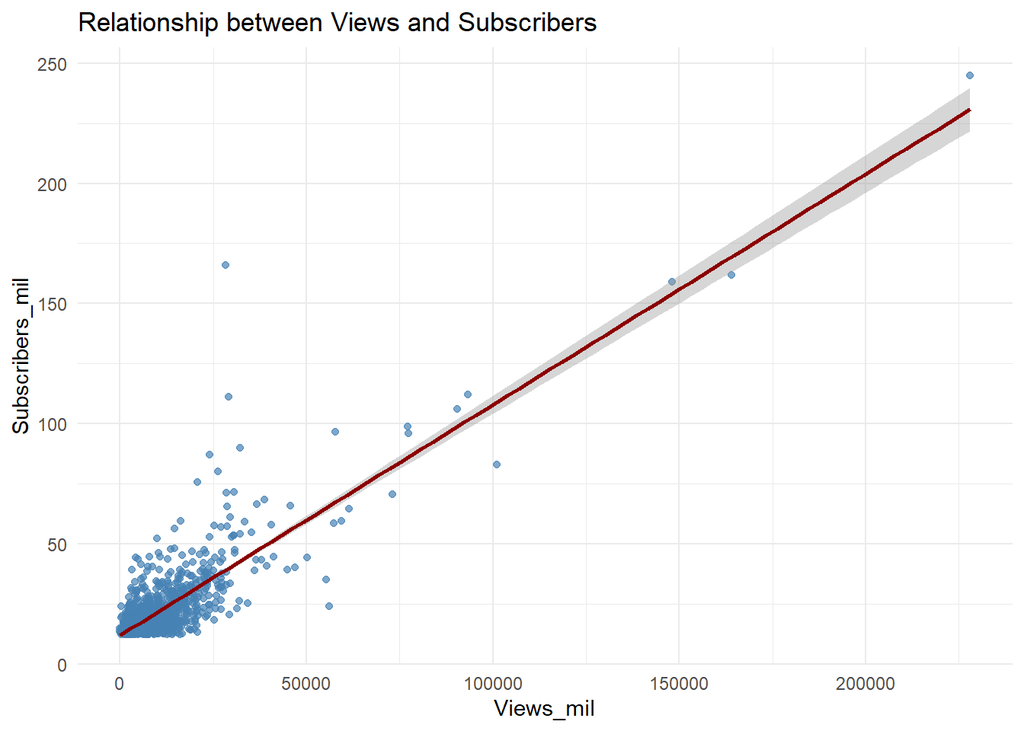

```r
# Subscribers by Views
ggplot(youtube_clean, aes(x = video_views_mil, y = subscribers_mil)) +
  geom_point(color = "steelblue", alpha = 0.7) +
  geom_smooth(method = "lm", se = TRUE, color = "darkred") +
  labs(
    title = "Relationship between Views and Subscribers",
    x = "Views_mil",
    y = "Subscribers_mil"
  ) +
  theme_minimal()
```

```r
cor(youtube_clean$video_views_mil, youtube_clean$subscribers_mil, use = "complete.obs")
```

```
## [1] 0.8253516
```

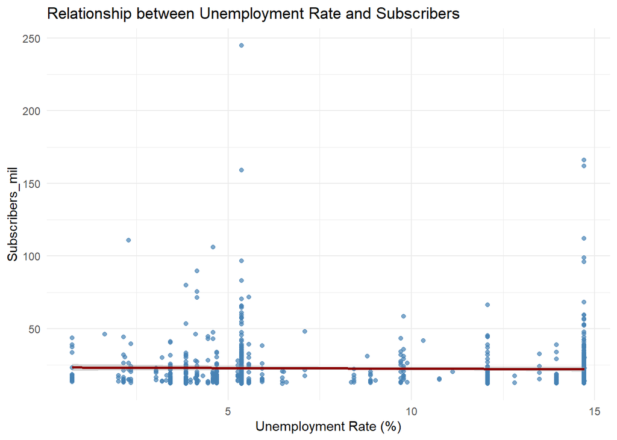

```r
# Subscribers by Unemployment Rate
ggplot(youtube_clean, aes(x = unemployment_rate, y = subscribers_mil)) +
  geom_point(color = "steelblue", alpha = 0.7) +
  geom_smooth(method = "lm", se = TRUE, color = "darkred") +
  labs(
    title = "Relationship between Unemployment Rate and Subscribers",
    x = "Unemployment Rate (%)",
    y = "Subscribers_mil"
  ) +
  theme_minimal()
```

```r
cor(youtube_clean$unemployment_rate, youtube_clean$subscribers_mil, use = "complete.obs")
```

```
## [1] -0.02443666
```

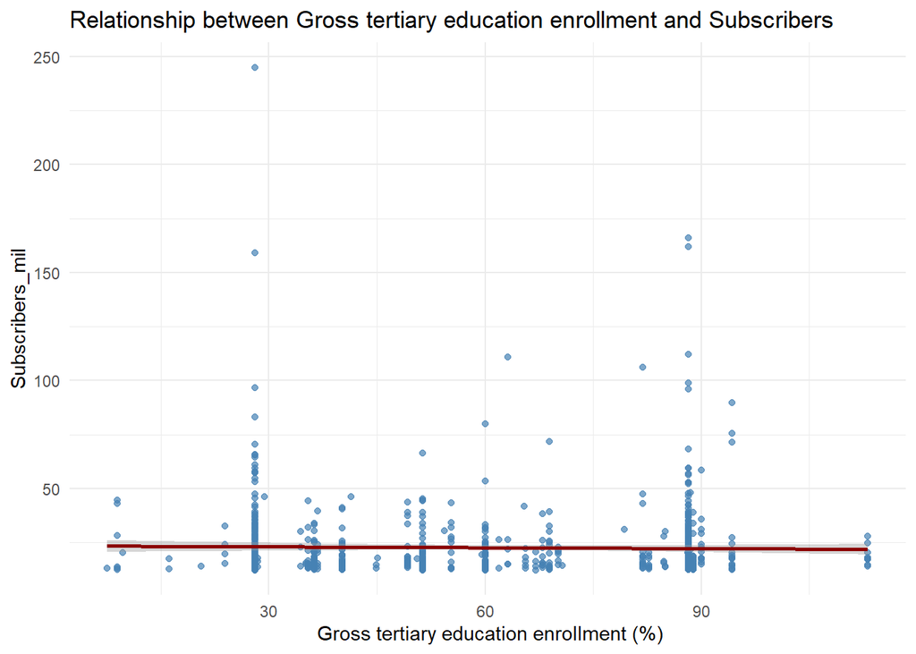

```r
# Subscribers by Gross tertiary education enrollment
ggplot(youtube_clean, aes(x =gross_tertiary_education_enrollment, y = subscribers_mil)) +
  geom_point(color = "steelblue", alpha = 0.7) +
  geom_smooth(method = "lm", se = TRUE, color = "darkred") +
  labs(
    title = "Relationship between Gross tertiary education enrollment and Subscribers",
    x = " Gross tertiary education enrollment (%)",
    y = "Subscribers_mil"
  ) +
  theme_minimal()
```

```r
cor(youtube_clean$gross_tertiary_education_enrollment, youtube_clean$subscribers_mil, use = "complete.obs")
```

```
## [1] -0.0209427
```